# p8105_hw6_ts3349

Tessa Senders

12/5/2020

```r
library(tidyverse)
library(broom)
library(p8105.datasets)
library(purrr)
library(modelr)
library(kableExtra)
```

## Problem 1

Read in homicide data.

```r
homicide_df =
  read_csv("./data/homicide-data.csv", na = c("", "NA", "Unknown")) %>%
  mutate(
    city_state = str_c(city, state, sep = ", "),
    victim_age = as.numeric(victim_age),
    resolution = case_when(
    disposition == "Closed without arrest" ~ 0,
    disposition == "Open/No arrest" ~ 0,
    disposition == "Closed by arrest" ~ 1)
  ) %>%
  filter(victim_race %in% c("White", "Black"),
    city_state != "Tulsa, AL") %>%
  select(city_state, resolution, victim_age, victim_race, victim_sex)
```

Generate a table of Confidence Intervals for the Odds Ratios

```r
baltimore_df =
  homicide_df %>%
  filter(city_state == "Baltimore, MD")

glm(resolution ~ victim_age + victim_race + victim_sex, data = baltimore_df, family = binomial()) %>% broom::tidy() %>%
  mutate(OR = exp(estimate),
         CI_lower = exp(estimate -1.96 * std.error),
         CI_upper = exp(estimate + 1.96 * std.error)) %>%
  select(term, OR, starts_with("CI")) %>%
  knitr::kable(digits = 3)
```

| term | OR | CI_lower | CI_upper |
| --- | --- | --- | --- |
| (Intercept) | 1.363 | 0.975 | 1.907 |
| victim_age | 0.993 | 0.987 | 1.000 |
| victim_raceWhite | 2.320 | 1.648 | 3.268 |
| victim_sexMale | 0.426 | 0.325 | 0.558 |

Fix data to then generate a plot of confidence intervals.

```r
models_results_df =
  homicide_df %>%
  nest(data = -city_state) %>%
  mutate(
    models =
      map(.x = data, ~glm(resolution ~ victim_age + victim_race + victim_sex, data = .x, family = binomial())),
    results = map(models, broom::tidy)
  ) %>%
    select(city_state, results) %>%
  unnest(results) %>%
  mutate(OR = exp(estimate),
         CI_lower = exp(estimate -1.96 * std.error),
         CI_upper = exp(estimate + 1.96 * std.error)) %>%
  select(city_state, term, OR, starts_with("CI"))
```

Create a plot of Confidence Intervals

[figure not shown]

```r
models_results_df %>%
  filter(term == "victim_sexMale") %>%
  mutate(city_state = fct_reorder(city_state, OR)) %>%
  ggplot(aes(x = city_state, y = OR)) +
  geom_point() +
  geom_errorbar(aes(ymin = CI_lower, ymax = CI_upper)) +
  theme(axis.text = element_text(angle = 270, vjust = 0.5, hjust = 1)) +
  labs(
    title = "Confidence Intervals for The Odds Ratios of \n Unsolved Homicides by Sex in Various Cities",
    x = "City and State",
    y = "Odds Ratio(OR)",
    caption = "Data from the Washington Post GitHub")
```

Most of the odds ratios are less than 1, indicating that the outcome (resolution, i.e. closed with an arrest) is often less likely for male homicide victims than for female homicide victims.

## Problem 2

Read in birthweight data and check that there are no missing values (there are no missing values).

```r
birthweight_df <- read_csv("./data/birthweight.csv") %>%
  janitor::clean_names() %>%
  mutate(babysex = as_factor(babysex),
         frace = as_factor(frace),
         malform = as_factor(malform),
         mrace = as_factor(mrace))
```

```r
birthweight_df %>%
  map(~sum(is.na(.)))
```

```
## $babysex
## [1] 0
##
## $bhead
## [1] 0
##
## $blength
## [1] 0
##
## $bwt
## [1] 0
##
## $delwt
## [1] 0
##
## $fincome
## [1] 0
##
## $frace
## [1] 0
##
## $gaweeks
## [1] 0
##
## $malform
## [1] 0
##
## $menarche
## [1] 0
##
## $mheight
## [1] 0
##
## $momage
## [1] 0
##
## $mrace
## [1] 0
##
## $parity
## [1] 0
##
## $pnumlbw
## [1] 0
##
## $pnumsga
## [1] 0
##
## $ppbmi
## [1] 0
##
## $ppwt
## [1] 0
##
## $smoken
## [1] 0
##
## $wtgain
## [1] 0
```

Create a prelimiary model using backward stepwise selection.

```r
full_model_bw <- lm(bwt ~ ., data = birthweight_df)
step(full_model_bw, direction='backward')
```

```
## Start:  AIC=48717.83
## bwt ~ babysex + bhead + blength + delwt + fincome + frace + gaweeks +
##     malform + menarche + mheight + momage + mrace + parity +
##     pnumlbw + pnumsga + ppbmi + ppwt + smoken + wtgain
##
##
## Step:  AIC=48717.83
## bwt ~ babysex + bhead + blength + delwt + fincome + frace + gaweeks +
##     malform + menarche + mheight + momage + mrace + parity +
##     pnumlbw + pnumsga + ppbmi + ppwt + smoken
##
##
## Step:  AIC=48717.83
## bwt ~ babysex + bhead + blength + delwt + fincome + frace + gaweeks +
##     malform + menarche + mheight + momage + mrace + parity +
##     pnumlbw + ppbmi + ppwt + smoken
##
##
## Step:  AIC=48717.83
## bwt ~ babysex + bhead + blength + delwt + fincome + frace + gaweeks +
##     malform + menarche + mheight + momage + mrace + parity +
##     ppbmi + ppwt + smoken
##
##            Df Sum of Sq       RSS   AIC
## - frace     4    124365 320848704 48712
## - malform   1      1419 320725757 48716
## - ppbmi     1      6346 320730684 48716
## - momage    1     28661 320752999 48716
## - mheight   1     66886 320791224 48717
## - menarche  1    111679 320836018 48717
## - ppwt      1    131132 320855470 48718
## <none>                  320724338 48718
## - fincome   1    193454 320917792 48718
## - parity    1    413584 321137922 48721
## - mrace     3    868321 321592659 48724
## - babysex   1    853796 321578134 48727
## - gaweeks   1   4611823 325336161 48778
## - smoken    1   5076393 325800732 48784
## - delwt     1   8008891 328733230 48823
## - blength   1 102050296 422774634 49915
```

[output cut: 88 more lines]

```
##     mheight + mrace + parity + ppwt + smoken
##
##           Df Sum of Sq       RSS   AIC
## <none>                 320986412 48705
## - fincome  1    245637 321232048 48707
## - parity   1    422770 321409181 48709
## - babysex  1    846134 321832545 48715
## - mheight  1   1012240 321998651 48717
## - ppwt     1   2907049 323893461 48743
## - gaweeks  1   4662501 325648912 48766
## - smoken   1   5073849 326060260 48771
## - delwt    1   8137459 329123871 48812
## - mrace    3  14683609 335670021 48894
## - blength  1 102191779 423178191 49903
## - bhead    1 106779754 427766166 49950
```

```
##
## Call:
## lm(formula = bwt ~ babysex + bhead + blength + delwt + fincome +
##     gaweeks + mheight + mrace + parity + ppwt + smoken, data = birthweight_df)
##
## Coefficients:
## (Intercept)     babysex2        bhead      blength        delwt      fincome
##   -6098.822       28.558      130.777       74.947        4.107        0.318
##     gaweeks      mheight       mrace2       mrace3       mrace4       parity
##      11.592        6.594     -138.792      -74.887     -100.678       96.305
##        ppwt       smoken
##      -2.676       -4.843
```

Compare the model generated from backward stepwise selection with the same model now including mother’s age at delivery (momage) as a covariate.

```r
my_model_poten_1 <- lm(bwt ~ babysex + bhead + blength + delwt + fincome +
    gaweeks + mheight + mrace + parity + ppwt + smoken, data = birthweight_df)

my_model_poten_2 <- lm(bwt ~ babysex + bhead + blength + delwt + fincome +
    gaweeks + mheight + mrace + parity + ppwt + smoken + momage, data = birthweight_df)

anova(my_model_poten_1,my_model_poten_2)
```

```
## Analysis of Variance Table
##
## Model 1: bwt ~ babysex + bhead + blength + delwt + fincome + gaweeks +
##     mheight + mrace + parity + ppwt + smoken
## Model 2: bwt ~ babysex + bhead + blength + delwt + fincome + gaweeks +
##     mheight + mrace + parity + ppwt + smoken + momage
##   Res.Df       RSS Df Sum of Sq      F Pr(>F)
## 1   4328 320986412
## 2   4327 320974714  1     11698 0.1577 0.6913
```

```r
summary(my_model_poten_1)
```

```
##
## Call:
## lm(formula = bwt ~ babysex + bhead + blength + delwt + fincome +
##     gaweeks + mheight + mrace + parity + ppwt + smoken, data = birthweight_df)
##
## Residuals:
##      Min       1Q   Median       3Q      Max
## -1097.18  -185.52    -3.39   174.14  2353.44
##
## Coefficients:
##               Estimate Std. Error t value Pr(>|t|)
## (Intercept) -6098.8219   137.5463 -44.340  < 2e-16 ***
## babysex2       28.5580     8.4549   3.378 0.000737 ***
## bhead         130.7770     3.4466  37.944  < 2e-16 ***
## blength        74.9471     2.0190  37.120  < 2e-16 ***
## delwt           4.1067     0.3921  10.475  < 2e-16 ***
## fincome         0.3180     0.1747   1.820 0.068844 .
## gaweeks        11.5925     1.4621   7.929 2.79e-15 ***
## mheight         6.5940     1.7849   3.694 0.000223 ***
## mrace2       -138.7925     9.9071 -14.009  < 2e-16 ***
## mrace3        -74.8868    42.3146  -1.770 0.076837 .
## mrace4       -100.6781    19.3247  -5.210 1.98e-07 ***
## parity         96.3047    40.3362   2.388 0.017004 *
## ppwt           -2.6756     0.4274  -6.261 4.20e-10 ***
## smoken         -4.8434     0.5856  -8.271  < 2e-16 ***
## ---
## Signif. codes:  0 '***' 0.001 '**' 0.01 '*' 0.05 '.' 0.1 ' ' 1
##
## Residual standard error: 272.3 on 4328 degrees of freedom
## Multiple R-squared:  0.7181, Adjusted R-squared:  0.7173
## F-statistic: 848.1 on 13 and 4328 DF,  p-value: < 2.2e-16
```

```r
summary(my_model_poten_2)
```

```
##
## Call:
## lm(formula = bwt ~ babysex + bhead + blength + delwt + fincome +
##     gaweeks + mheight + mrace + parity + ppwt + smoken + momage,
##     data = birthweight_df)
##
## Residuals:
##      Min       1Q   Median       3Q      Max
## -1096.89  -185.07    -3.27   173.59  2353.58
##
## Coefficients:
##               Estimate Std. Error t value Pr(>|t|)
## (Intercept) -6105.2756   138.5164 -44.076  < 2e-16 ***
## babysex2       28.6631     8.4599   3.388  0.00071 ***
## bhead         130.7595     3.4472  37.932  < 2e-16 ***
## blength        74.9612     2.0196  37.118  < 2e-16 ***
## delwt           4.1216     0.3939  10.464  < 2e-16 ***
## fincome         0.3030     0.1788   1.695  0.09016 .
## gaweeks        11.5598     1.4645   7.893 3.70e-15 ***
## mheight         6.5812     1.7854   3.686  0.00023 ***
## mrace2       -137.8327    10.1986 -13.515  < 2e-16 ***
## mrace3        -77.0722    42.6751  -1.806  0.07098 .
## mrace4       -100.2602    19.3552  -5.180 2.32e-07 ***
## parity         95.0905    40.4558   2.350  0.01879 *
## ppwt           -2.7014     0.4323  -6.249 4.54e-10 ***
## smoken         -4.8426     0.5856  -8.269  < 2e-16 ***
## momage          0.4758     1.1981   0.397  0.69131
## ---
## Signif. codes:  0 '***' 0.001 '**' 0.01 '*' 0.05 '.' 0.1 ' ' 1
##
## Residual standard error: 272.4 on 4327 degrees of freedom
## Multiple R-squared:  0.7181, Adjusted R-squared:  0.7172
## F-statistic: 787.4 on 14 and 4327 DF,  p-value: < 2.2e-16
```

Choose the smaller model and plot the residuals vs fitted values.

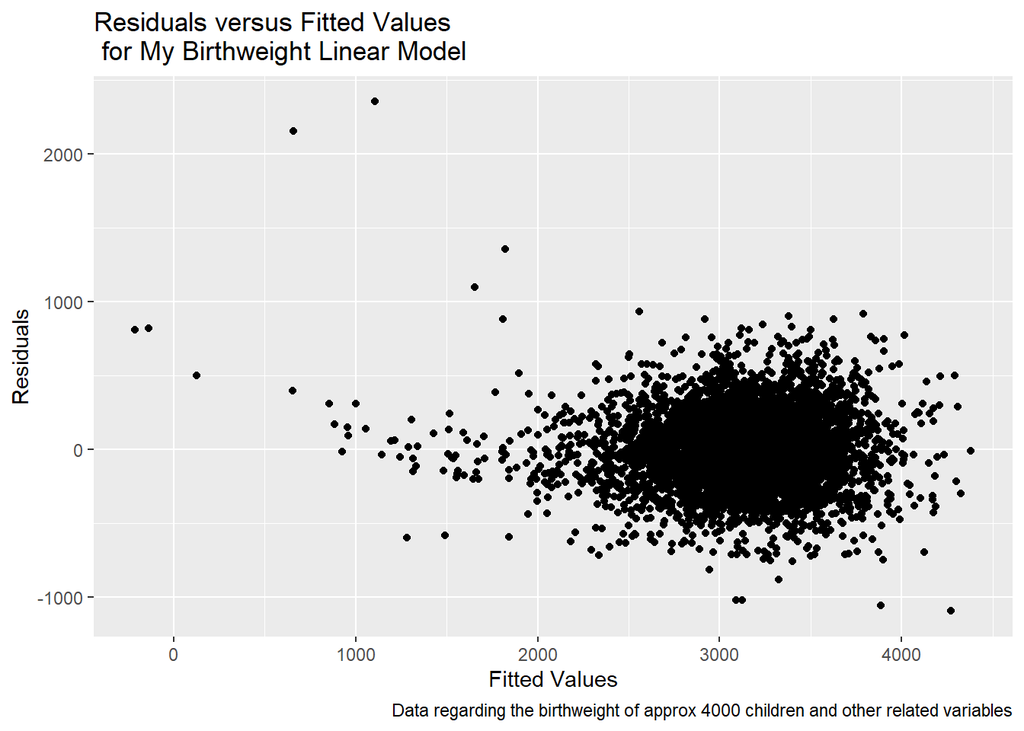

```r
my_model_fit = lm(bwt ~ babysex + bhead + blength + delwt + fincome +
    gaweeks + mheight + mrace + parity + ppwt + smoken, data = birthweight_df)

birthweight_df %>%
modelr::add_residuals(my_model_fit) %>%
modelr::add_predictions(my_model_fit) %>%
  ggplot(aes(x = pred, y = resid)) + geom_point() +
  labs(
    title = "Residuals versus Fitted Values \n for My Birthweight Linear Model",
    x = "Fitted Values",
    y = "Residuals",
    caption = "Data regarding the birthweight of approx 4000 children and other related variables"
  )
```

Use cross-validation to compare the three models. Plot the RMSEs for each model.

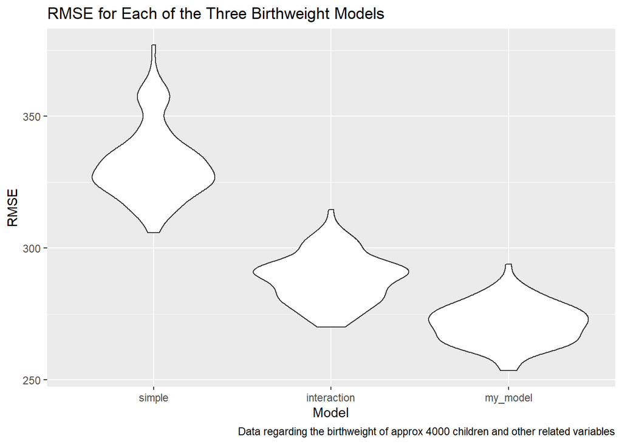

```r
set.seed(1)
fit_1 = lm(bwt ~ blength + gaweeks, data = birthweight_df)
fit_2 = lm(bwt ~ bhead * blength * babysex, data = birthweight_df)

cv_df =
  crossv_mc(birthweight_df, 100) %>%
  mutate(
    train = map(train, as_tibble),
    test = map(test, as_tibble))

cv_df =
  cv_df %>%
  mutate(
    simple_model = map(train, ~lm(bwt ~ blength + gaweeks, data = .x)),
    interaction_model = map(train, ~lm(bwt ~ bhead * blength * babysex, data = .x)),
    my_model = map(train, ~lm(bwt ~ babysex + bhead + blength + delwt + fincome +
    gaweeks + mheight + mrace + parity + ppwt + smoken, data = birthweight_df))
  ) %>%

  mutate(
    rmse_simple = map2_dbl(simple_model, test, ~rmse(model = .x, data = .y)),
    rmse_interaction = map2_dbl(interaction_model, test, ~rmse(model = .x, data = .y)),
    rmse_my_model = map2_dbl(my_model, test, ~rmse(model = .x, data = .y))
    )

cv_df %>%
  select(starts_with("rmse")) %>%
  pivot_longer(
    everything(),
    names_to = "model",
    values_to = "rmse",
    names_prefix = "rmse_") %>%
  mutate(model = fct_inorder(model)) %>%
  ggplot(aes(x = model, y = rmse)) + geom_violin() +
  labs(
    title = "RMSE for Each of the Three Birthweight Models",
    x = "Model",
    y = "RMSE",
    caption = "Data regarding the birthweight of approx 4000 children and other related variables"
  )
```

I started by building a preliminary model using backward stepwise regression. After that I compared that model to the same model that also included the covariate momage (the mother’s age at delivery in years) because I had previously read that the age of the mother can have significant impacts on the birth of the child including its birthweight. I compared the two models using ANOVA (they were nested models), but found that adding the covariate momage to the original model generated by backward stepwise regression did not improve the model. So in the end, my final model was the one I found after performing backward stepwise regression.

My model seems to be the best model out of the three proposed models since it clearly has the lowest average RMSE. The simple model that included the covariates birth and gestational age has the highest average RMSE. The model that uses head circumference, length, sex, and all interactions performs better than the simple model but still has a higher average RMSE than my proposed model created from backward stepwise regression.

## Problem 3

Load weather data.

```r
weather_df =
  rnoaa::meteo_pull_monitors(
    c("USW00094728"),
    var = c("PRCP", "TMIN", "TMAX"),
    date_min = "2017-01-01",
    date_max = "2017-12-31") %>%
  mutate(
    name = recode(id, USW00094728 = "CentralPark_NY"),
    tmin = tmin / 10,
    tmax = tmax / 10) %>%
  select(name, id, everything())
```

```
## using cached file: C:\Users\tsilo\AppData\Local\Cache/R/noaa_ghcnd/USW00094728.dly
```

```
## date created (size, mb): 2020-12-05 15:20:44 (7.552)
```

```
## file min/max dates: 1869-01-01 / 2020-12-31
```

Draw bootstrap samples.

```r
set.seed(1)

boot_sample = function(df) {
  sample_frac(df, replace = TRUE)
}

boot_straps =
  data_frame(
    strap_number = 1:5000,
    strap_sample = rerun(5000, boot_sample(weather_df))
  )
```

```r
bootstrap_results =
  boot_straps %>%
  mutate(
    models = map(strap_sample, ~lm(tmax ~ tmin, data = .x)),
    results = map(models, broom::glance),
    results_2 = map(models, broom::tidy)) %>%
  select(-strap_sample, -models) %>%
  unnest(results,
         results_2) %>%
  select(strap_number, r.squared, term, estimate) %>%
  pivot_wider(names_from = term,
              values_from = estimate) %>%
  janitor::clean_names() %>%
  mutate(log_value = log(intercept * tmin))
head(bootstrap_results)
```

```
## # A tibble: 6 x 5
##   strap_number r_squared intercept  tmin log_value
##          <int>     <dbl>     <dbl> <dbl>     <dbl>
## 1            1     0.907      7.45 1.03       2.04
## 2            2     0.896      7.36 1.03       2.03
## 3            3     0.918      7.48 1.04       2.05
## 4            4     0.899      7.91 0.998      2.07
## 5            5     0.913      6.73 1.07       1.97
## 6            6     0.919      6.87 1.06       1.99
```

Generate plots showing bootstrap results.

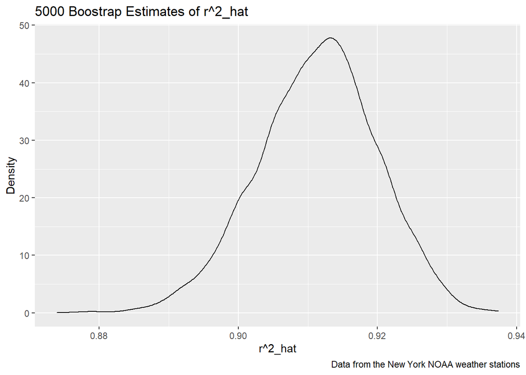

```r
bootstrap_results %>%
  ggplot(aes(x = r_squared)) +
  geom_density() +
  labs(
    title = "5000 Boostrap Estimates of r^2_hat",
    x = "r^2_hat",
    y = "Density",
    caption = "Data from the New York NOAA weather stations"
  )
```

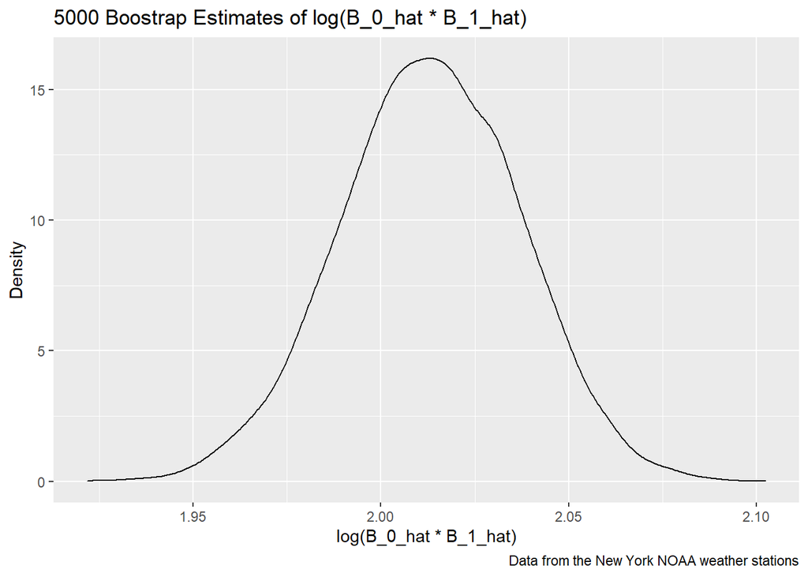

```r
bootstrap_results %>%
  ggplot(aes(x = log_value)) +
  geom_density()+
  labs(
    title = "5000 Boostrap Estimates of log(B_0_hat * B_1_hat)",
    x = "log(B_0_hat * B_1_hat)",
    y = "Density",
    caption = "Data from the New York NOAA weather stations"
  )
```

The distributions of both the R^2 values and the log(B_0_hat*B_1_hat) values seem to follow fairly normal distributions. For the distribution of R^2 values, the plot seems to be slightly skewed left. The mean of the distribution seems to be around 0.91. For the distribution of log(B_0_hat times B_1_hat), the mean of the distribution seems to be around 2.0125.

Generate confidence intervals from the bootstrap results.

```r
bootstrap_results %>%
  summarize(
    ci_lower_rsqd = quantile(r_squared, 0.025),
    ci_upper_rsqd = quantile(r_squared, 0.975),
    ci_lower_log = quantile(log_value, 0.025),
    ci_upper_log = quantile(log_value, 0.975)) %>%
  rename(`R^2 Lower CI` = ci_lower_rsqd,
         `R^2 Upper CI` = ci_upper_rsqd,
         `log(B_0_hat*B_1_hat) Lower CI` = ci_lower_log,
         `log(B_0_hat*B_1_hat) Upper CI` = ci_upper_log) %>%
  kbl(caption = "95% Confidence Intervals for R^2_hat and log(B_0_hat*B_1_hat)") %>%
  kable_classic(full_width = F, html_font = "Cambria")
```

95% Confidence Intervals for R^2_hat and log(B_0_hat*B_1_hat)

| R^2 Lower CI | R^2 Upper CI | log(B_0_hat*B_1_hat) Lower CI | log(B_0_hat*B_1_hat) Upper CI |
| --- | --- | --- | --- |
| 0.8936684 | 0.927106 | 1.964949 | 2.058887 |